# hyperSpec Package Review

Tuesday, October 30, 2018

#Background

## Spectra - What are they?

- “a specific set of values that can vary infinitely within a continuum”
- Generally: 2-dimensional (sometimes higher) dimensional data,
  - where the first dimension identifies points along a continuum,
  - and the second dimension the values of a response of interest
  - at the corresponding points
- Examples: Optical, Mass, Political Alignment

## Spectral Data - How do we store them?

- Proprietary file format: not so useful
- .csv files (ASCII): better ~ excel, R
- .spc files (Binary): good ~ R

## hyperSpec - How to manipulate .spc files in R

- http://hyperspec.r-forge.r-project.org/
- Handles spectral data
- Features: Convenient import, spectral range selection, shfiting, plotting/viewing, normalization, smoothing, correction, arithmetic, initial data analysis

#hyperSpec Examples

[output not shown]

## File Import

```r
# Read one .spc file and check its structure
# setwd("V:/vuv-data/instr/spectra/")
curfile <- "./data/pet_unstab_cyclic_quv/sa19603_00_ex320.spc"
step0 <- read.spc(curfile)
class(step0)
```

```
## [1] "hyperSpec"
## attr(,"package")
## [1] "hyperSpec"
```

```r
step0
```

```
## hyperSpec object
##    1 spectra
##    4 data columns
##    301 data points / spectrum
## wavelength: lambda/nm [numeric] 330.00 331.07 ... 630
## data:  (1 rows x 4 columns)
##    1. z: x/"a. u." [numeric] 0
##    2. z.end: x/"a. u." [numeric] 0
##    3. spc: I/"a. u." [matrix301] 95.5881 98.6830 ... 94.45682
##    4. filename: filename [character] ./data/pet_unstab_cyclic_quv/sa19603_00_ex320.spc
```

## Basic Plotting

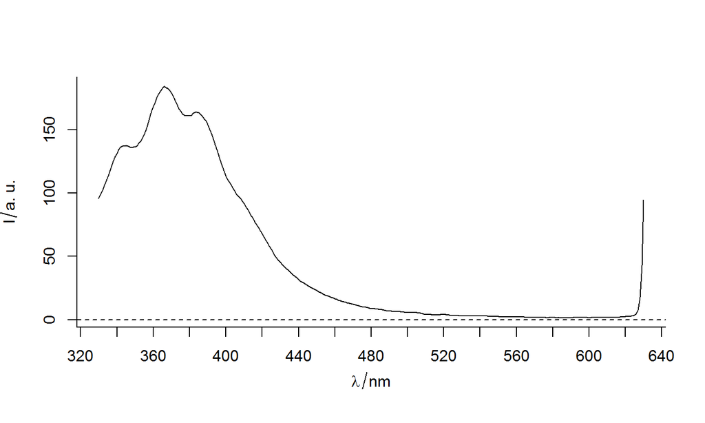

```r
#Plot with hyperSpec base plotting

plotspc(step0)
```

## Multiple .spc Files?

- (Purposefully without a loop or apply)

```r
# Read multiple .spc files

#setwd("./data/pet_unstab_cyclic_quv_ex320/")
curfile <- "./data/pet_unstab_cyclic_quv/sa19603_00_ex320.spc"
step0 <- read.spc(curfile)
curfile <- "./data/pet_unstab_cyclic_quv/sa19603_22_ex320.spc"
step1 <- read.spc(curfile)
curfile <- "./data/pet_unstab_cyclic_quv/sa19603_23_ex320.spc"
step2 <- read.spc(curfile)
curfile <- "./data/pet_unstab_cyclic_quv/sa19603_24_ex320.spc"
step3 <- read.spc(curfile)
curfile <- "./data/pet_unstab_cyclic_quv/sa19603_25_ex320.spc"
step4 <- read.spc(curfile)
curfile <- "./data/pet_unstab_cyclic_quv/sa19603_26_ex320.spc"
step5 <- read.spc(curfile)
curfile <- "./data/pet_unstab_cyclic_quv/sa19603_27_ex320.spc"
step6 <- read.spc(curfile)
curfile <- "./data/pet_unstab_cyclic_quv/sa19603_28_ex320.spc"
step7 <- read.spc(curfile)
```

## Combine into one object (Good News!)

```r
# Use Collpase to combine spectra

spec <- hyperSpec::collapse(step0, step1, step2, step3, step4, step5, step6, step7)
class(spec)
```

```
## [1] "hyperSpec"
## attr(,"package")
## [1] "hyperSpec"
```

```r
spec
```

```
## hyperSpec object
##    8 spectra
##    4 data columns
##    301 data points / spectrum
## wavelength: lambda/nm [numeric] 330.00 331.07 ... 630
## data:  (8 rows x 4 columns)
##    1. z: x/"a. u." [numeric] 0 0 ... 0
##    2. z.end: x/"a. u." [numeric] 0 0 ... 0
##    3. spc: I/"a. u." [matrix301] 95.58810 18.86919 ... 1000
##    4. filename: filename [character] ./data/pet_unstab_cyclic_quv/sa19603_00_ex320.spc ./data/pet_unstab_cyclic_quv/sa19603_22_ex320.spc ... ./data/pet_unstab_cyclic_quv/sa19603_28_ex320.spc
```

## Basic Plotting

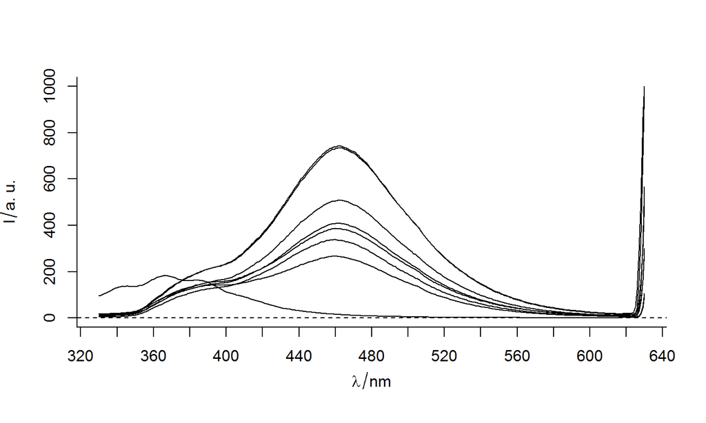

```r
plotspc(spec)
```

## Spectral Range Selection

```r
#Subset and redifine the hyperSpec object according to wavelength

spec <- spec[,, min ~ 600]
spec
```

```
## hyperSpec object
##    8 spectra
##    4 data columns
##    271 data points / spectrum
## wavelength: lambda/nm [numeric] 330.00 331.07 ... 600
## data:  (8 rows x 4 columns)
##    1. z: x/"a. u." [numeric] 0 0 ... 0
##    2. z.end: x/"a. u." [numeric] 0 0 ... 0
##    3. spc: I/"a. u." [matrix271] 95.58810 18.86919 ... 25.40894
##    4. filename: filename [character] ./data/pet_unstab_cyclic_quv/sa19603_00_ex320.spc ./data/pet_unstab_cyclic_quv/sa19603_22_ex320.spc ... ./data/pet_unstab_cyclic_quv/sa19603_28_ex320.spc
```

## Basic Plotting

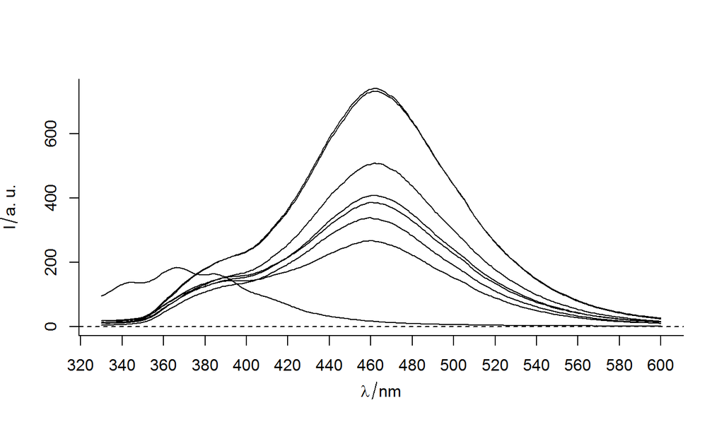

```r
plotspc(spec)
```

## Spectral Arithmetic (Subtraction)

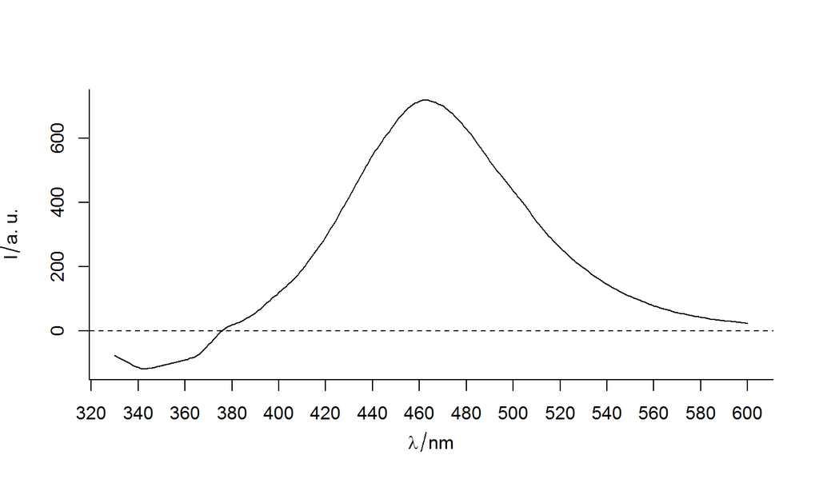

```r
#Perform spectral subtraction

sub <- step7 - step0
plotspc(sub[,, min ~ 600])
```

## Removing Bad Data

```r
# Let's look at some fake IR data
ir.spc <- chondro
ir.spc
```

```
## hyperSpec object
##    875 spectra
##    5 data columns
##    300 data points / spectrum
## wavelength: Delta * tilde(nu)/cm^-1 [numeric] 602 606 ... 1798
## data:  (875 rows x 5 columns)
##    1. y: y [numeric] -4.77 -4.77 ... 19.23
##    2. x: x [numeric] -11.55 -10.55 ... 22.45
##    3. filename: filename [character] rawdata/chondro.txt rawdata/chondro.txt ... rawdata/chondro.txt
##    4. clusters: clusters [factor] matrix matrix ... lacuna + NA
##    5. spc: I / a.u. [matrix300] 501.8194 500.4552 ... 169.2942
```

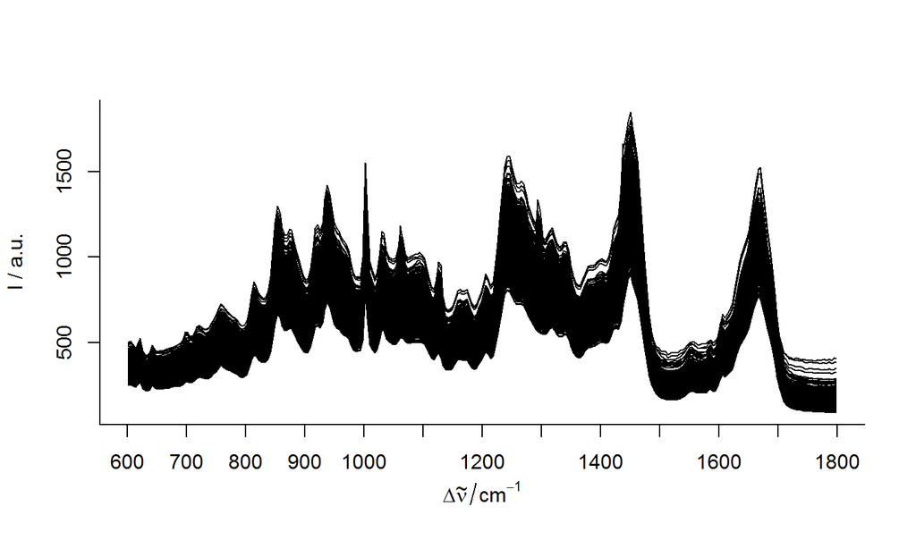

```r
plotspc(ir.spc, spc.nmax = length(ir.spc))
```

## Removing Bad Data

```r
#Define any point above 1500 as bad
high.int <- apply(ir.spc > 1500, 1, any)

#Maximum should atleast be 0.1
low.int <- apply(ir.spc, 1, max) < 0.1

#Apply Conditions
ir.spc <- ir.spc[!high.int & !low.int]
```

## Removed the bad spectra

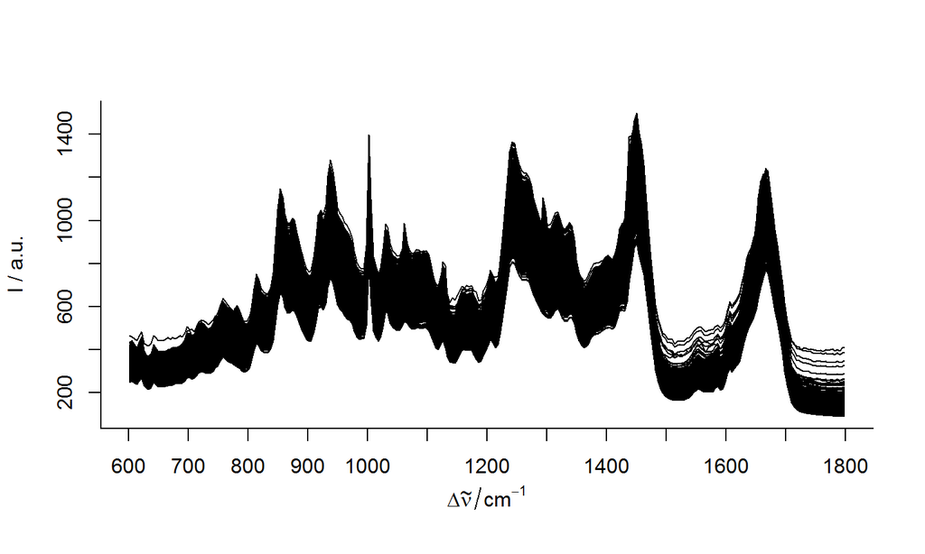

```r
plotspc(ir.spc, spc.nmax = length(ir.spc))
```

```r
# Apply basline correction function
blcorr <- spc.fit.poly.below(ir.spc)

# Subtract away correction from original
ir.spc <- ir.spc - blcorr
```

## Corrected Spectra!

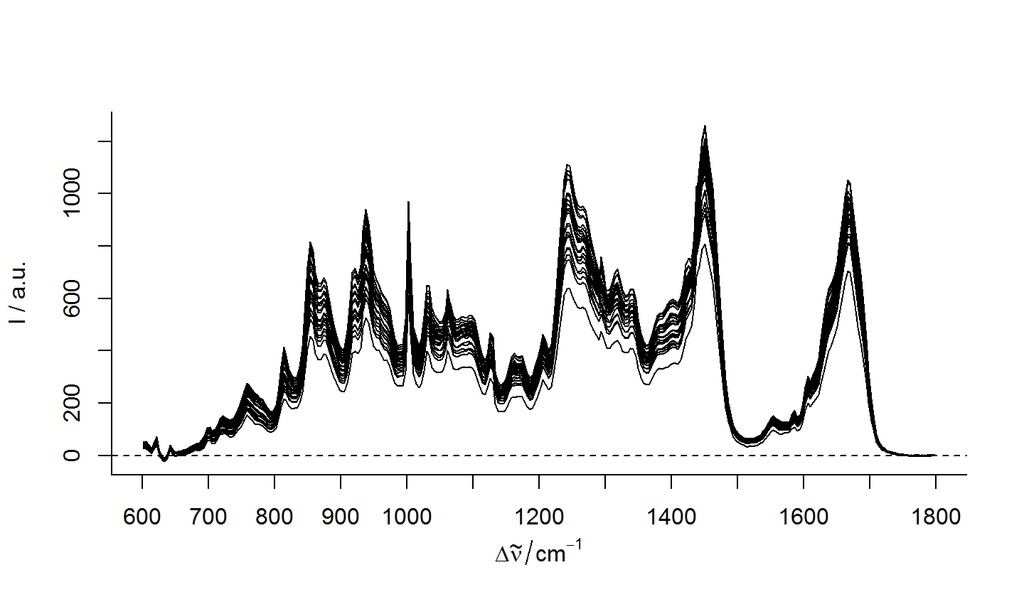

```r
plotspc(ir.spc)
```

## Example of use

## Load Cyclic QUV Absorbance Data Set

```r
# setwd("v:/vuv-data/proj/3M")

## Read keyfile(s) and set classes

pet.key <- read.csv("./data/pet_unstab_cyclic_quv/3m_sample_key.csv")
pet.key$Sample <- as.character(pet.key$Sample)
pet.key$Product <- as.character(pet.key$Product)
pet.key$Exposure <- as.character(pet.key$Exposure)
pet.key$Step_Retained <- as.character(pet.key$Step_Retained)

## Read step 0 (Unexposed) CyclicQUV Optical Absorbance Data

filenames <- list.files(path = "./data/pet_unstab_cyclic_quv/Cary/CyclicQUV/step0/", pattern = "\\.spc$")

# Read Files

cq.abs.step0  <- lapply(filenames,function(i){
  read.spc(paste("./data/pet_unstab_cyclic_quv/Cary/CyclicQUV/step0/",i,sep = ""))
})

# Combine resulting list into one hyperSpec object

cq.abs.step0 <- hyperSpec::collapse(cq.abs.step0[1:length(cq.abs.step0)])

# Add step data

cq.abs.step0@data$step <- 0


## Extract sample number from file name using sub (grep) to pull the sample number from the file name match to row in the keyfile

cq.abs.step0@data$sample <- filenames %>% sub(pattern = "-es00-ms00-mn01_uvvs01.spc",replacement = "") %>% sub(pattern ="_",replacement = ".")

# Match material info from key file and add to hyperSpec object

rows <- cq.abs.step0@data$sample %>% pmatch(pet.key[,1])
cq.abs.step0@data$material <- pet.key[rows,2]

## Read step 1 CyclicQUV Optical Absorbance Data

filenames <- list.files(path = "./data/pet_unstab_cyclic_quv/Cary/CyclicQUV/step1/", pattern = "\\.SPC$")

# Read Files

cq.abs.step1  <- lapply(filenames,function(i){
  read.spc(paste("./data/pet_unstab_cyclic_quv/Cary/CyclicQUV/step1/",i,sep = ""))
})

# Combine resulting list into one hyperSpec object

cq.abs.step1 <- hyperSpec::collapse(cq.abs.step1[1:length(cq.abs.step1)])

# Add step data

cq.abs.step1@data$step <- 1


## Extract sample number from file name using sub (grep) to pull the sample number from the file name match to row in the keyfile

cq.abs.step1@data$sample <- filenames %>% sub(pattern = "-es01-ms01-mn01_uvvs01.SPC",replacement = "") %>% sub(pattern ="_",replacement = ".")

# Match material info from key file and add to hyperSpec object

rows <- cq.abs.step1@data$sample %>% pmatch(pet.key[,1])
cq.abs.step1@data$material <- pet.key[rows,2]

## Read step 2 CyclicQUV Optical Absorbance Data

filenames <- list.files(path = "./data/pet_unstab_cyclic_quv/Cary/CyclicQUV/step2/", pattern = "\\.SPC$")

# Read Files

cq.abs.step2  <- lapply(filenames,function(i){
  read.spc(paste("./data/pet_unstab_cyclic_quv/Cary/CyclicQUV/step2/",i,sep = ""))
})

# Combine resulting list into one hyperSpec object

cq.abs.step2 <- hyperSpec::collapse(cq.abs.step2[1:length(cq.abs.step2)])

# Add step data

cq.abs.step2@data$step <- 2


## Extract sample number from file name using sub (grep) to pull the sample number from the file name match to row in the keyfile

cq.abs.step2@data$sample <- filenames %>% sub(pattern = "-es02-ms02-mn01_uvvs01.SPC",replacement = "") %>% sub(pattern ="_",replacement = ".")

# Match material info from key file and add to hyperSpec object

rows <- cq.abs.step2@data$sample %>% pmatch(pet.key[,1])
cq.abs.step2@data$material <- pet.key[rows,2]
```

Lets check out the contents of each hyperSpec Object

```r
cq.abs.step0
```

```
## hyperSpec object
##    6 spectra
##    7 data columns
##    3201 data points / spectrum
## wavelength: lambda/nm [numeric] 1800.0 1799.5 ... 200
## data:  (6 rows x 7 columns)
##    1. z: x/"a. u." [numeric] 0 0 ... 0
##    2. z.end: x/"a. u." [numeric] 0 0 ... 0
##    3. spc: A [matrix3201] 0.1272863 0.1177481 ... 0.2635259
##    4. filename: filename [character] ./data/pet_unstab_cyclic_quv/Cary/CyclicQUV/step0/sa25000_01-es00-ms00-mn01_uvvs01.spc ./data/pet_unstab_cyclic_quv/Cary/CyclicQUV/step0/sa25002_01-es00-ms00-mn01_uvvs01.spc ... ./data/pet_unstab_cyclic_quv/Cary/CyclicQUV/step0/sa25010_01-es00-ms00-mn01_uvvs01…
##    5. step:  [numeric] 0 0 ... 0
##    6. sample:  [character] sa25000.01 sa25002.01 ... sa25010.01
##    7. material:  [character] B-Melinex243 B-Melinex238 ... B-TeteronU2L92W
```

```r
cq.abs.step1
```

```
## hyperSpec object
##    54 spectra
##    7 data columns
##    3201 data points / spectrum
## wavelength: lambda/nm [numeric] 1800.0 1799.5 ... 200
## data:  (54 rows x 7 columns)
##    1. z: x/"a. u." [numeric] 0 0 ... 0
##    2. z.end: x/"a. u." [numeric] 0 0 ... 0
##    3. spc: A [matrix3201] 0.1714494 0.1342367 ... 0.2494305
##    4. filename: filename [character] ./data/pet_unstab_cyclic_quv/Cary/CyclicQUV/step1/sa25000_26-es01-ms01-mn01_uvvs01.SPC ./data/pet_unstab_cyclic_quv/Cary/CyclicQUV/step1/sa25000_27-es01-ms01-mn01_uvvs01.SPC ... ./data/pet_unstab_cyclic_quv/Cary/CyclicQUV/step1/sa25010_34-es01-ms01-mn01_uvvs01…
##    5. step:  [numeric] 1 1 ... 1
##    6. sample:  [character] sa25000.26 sa25000.27 ... sa25010.34
##    7. material:  [character] B-Melinex243 B-Melinex243 ... B-TeteronU2L92W
```

```r
cq.abs.step2
```

```
## hyperSpec object
##    48 spectra
##    7 data columns
##    3201 data points / spectrum
## wavelength: lambda/nm [numeric] 1800.0 1799.5 ... 200
## data:  (48 rows x 7 columns)
##    1. z: x/"a. u." [numeric] 0 0 ... 0
##    2. z.end: x/"a. u." [numeric] 0 0 ... 0
##    3. spc: A [matrix3201] -0.030848697 -0.001725956 ... 0.09484347
##    4. filename: filename [character] ./data/pet_unstab_cyclic_quv/Cary/CyclicQUV/step2/sa25000_27-es02-ms02-mn01_uvvs01.SPC ./data/pet_unstab_cyclic_quv/Cary/CyclicQUV/step2/sa25000_28-es02-ms02-mn01_uvvs01.SPC ... ./data/pet_unstab_cyclic_quv/Cary/CyclicQUV/step2/sa25010_34-es02-ms02-mn01_uvvs01…
##    5. step:  [numeric] 2 2 ... 2
##    6. sample:  [character] sa25000.27 sa25000.28 ... sa25010.34
##    7. material:  [character] B-Melinex243 B-Melinex243 ... B-TeteronU2L92W
```

We’ll put these all together

```r
# Combine cq.abs.step0s with step 1

cq.abs <- hyperSpec::collapse(cq.abs.step0, cq.abs.step1, cq.abs.step2)

cq.abs
```

```
## hyperSpec object
##    108 spectra
##    7 data columns
##    3201 data points / spectrum
## wavelength: lambda/nm [numeric] 1800.0 1799.5 ... 200
## data:  (108 rows x 7 columns)
##    1. z: x/"a. u." [numeric] 0 0 ... 0
##    2. z.end: x/"a. u." [numeric] 0 0 ... 0
##    3. spc: A [matrix3201] 0.1272863 0.1177481 ... 0.09484347
##    4. filename: filename [character] ./data/pet_unstab_cyclic_quv/Cary/CyclicQUV/step0/sa25000_01-es00-ms00-mn01_uvvs01.spc ./data/pet_unstab_cyclic_quv/Cary/CyclicQUV/step0/sa25002_01-es00-ms00-mn01_uvvs01.spc ... ./data/pet_unstab_cyclic_quv/Cary/CyclicQUV/step2/sa25010_34-es02-ms02-mn01_uvvs01…
##    5. step:  [numeric] 0 0 ... 2
##    6. sample:  [character] sa25000.01 sa25002.01 ... sa25010.34
##    7. material:  [character] B-Melinex243 B-Melinex238 ... B-TeteronU2L92W
```

## Utilizing spectral arithmetric to change ordinate axis

```r
# Divide by sample thickness for Abs/cm

t.melinex243 <- 0.005
t.melinex238 <- 0.0127
t.melinex626 <- 0.0127
t.melinex618 <- 0.0127
t.teteronu2 <- 0.005
t.teteronu2l92w <- 0.0125

for (i in 1:length(cq.abs@data$material)) {

  if (cq.abs@data$material[i] == "B-Melinex243") {cq.abs[i] <- cq.abs[i]/t.melinex243}
  if (cq.abs@data$material[i] == "B-Melinex238") {cq.abs[i] <- cq.abs[i]/t.melinex238}
  if (cq.abs@data$material[i] == "A-Melinex626") {cq.abs[i] <- cq.abs[i]/t.melinex626}
  if (cq.abs@data$material[i] == "A-Melinex618") {cq.abs[i] <- cq.abs[i]/t.melinex618}
  if (cq.abs@data$material[i] == "B-TeteronU2") {cq.abs[i] <- cq.abs[i]/t.teteronu2}
  if (cq.abs@data$material[i] == "B-TeteronU2L92W") {cq.abs[i] <- cq.abs[i]/t.teteronu2l92w}
}

cq.abs
```

```
## hyperSpec object
##    108 spectra
##    7 data columns
##    3201 data points / spectrum
## wavelength: lambda/nm [numeric] 1800.0 1799.5 ... 200
## data:  (108 rows x 7 columns)
##    1. z: x/"a. u." [numeric] 0 0 ... 0
##    2. z.end: x/"a. u." [numeric] 0 0 ... 0
##    3. spc: A [matrix3201] 25.457266 9.271504 ... 7.587478
##    4. filename: filename [character] ./data/pet_unstab_cyclic_quv/Cary/CyclicQUV/step0/sa25000_01-es00-ms00-mn01_uvvs01.spc ./data/pet_unstab_cyclic_quv/Cary/CyclicQUV/step0/sa25002_01-es00-ms00-mn01_uvvs01.spc ... ./data/pet_unstab_cyclic_quv/Cary/CyclicQUV/step2/sa25010_34-es02-ms02-mn01_uvvs01…
##    5. step:  [numeric] 0 0 ... 2
##    6. sample:  [character] sa25000.01 sa25002.01 ... sa25010.34
##    7. material:  [character] B-Melinex243 B-Melinex238 ... B-TeteronU2L92W
```

```r
# Remove errenous points (negative)

`cq.abs` [[`cq.abs` < 0]] <- NA

cq.abs
```

```
## hyperSpec object
##    108 spectra
##    7 data columns
##    3201 data points / spectrum
## wavelength: lambda/nm [numeric] 1800.0 1799.5 ... 200
## data:  (108 rows x 7 columns)
##    1. z: x/"a. u." [numeric] 0 0 ... 0
##    2. z.end: x/"a. u." [numeric] 0 0 ... 0
##    3. spc: A [matrix3201] 25.457266 9.271504 ... 7.587478 + NA
##    4. filename: filename [character] ./data/pet_unstab_cyclic_quv/Cary/CyclicQUV/step0/sa25000_01-es00-ms00-mn01_uvvs01.spc ./data/pet_unstab_cyclic_quv/Cary/CyclicQUV/step0/sa25002_01-es00-ms00-mn01_uvvs01.spc ... ./data/pet_unstab_cyclic_quv/Cary/CyclicQUV/step2/sa25010_34-es02-ms02-mn01_uvvs01…
##    5. step:  [numeric] 0 0 ... 2
##    6. sample:  [character] sa25000.01 sa25002.01 ... sa25010.34
##    7. material:  [character] B-Melinex243 B-Melinex238 ... B-TeteronU2L92W
```

## Better plotting using ggplot2 graphics

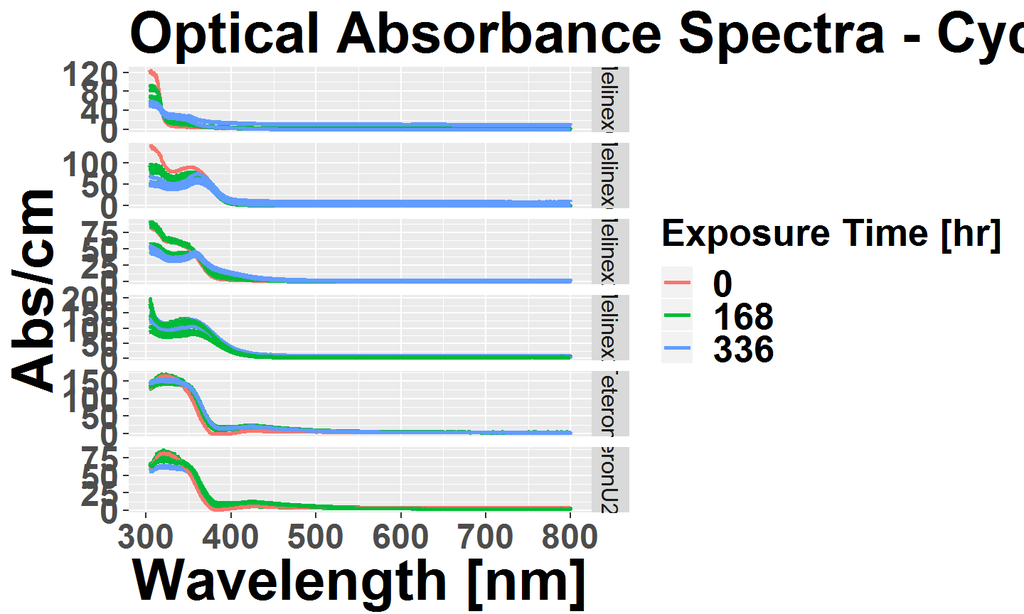

## Peak Information extraction

We can directly address the intensity value at a specific wavelength

```r
spec[2,,460]@data$spc
```

```
##           460
## [1,] 266.9985
```

Using this concept, we can also find full width at half max by approximating the wavelengths at half the intensity of the peak

```r
lower <- approx(spec[2,,330 ~ 460]$spc, spec[2,,330 ~ 460]@wavelength, xout = c(spec[2,,460]$spc/2))
lower
```

```
## $x
## [1] 133.4993
##
## $y
## [1] 383.7909
```

```r
upper <- approx(spec[2,,460 ~ 600]$spc, spec[2,,460 ~ 600]@wavelength, xout = c(spec[2,,460]$spc/2))
upper
```

```
## $x
## [1] 133.4993
##
## $y
## [1] 506.0615
```

```r
fwhm <- upper$y - lower$y
fwhm
```

```
## [1] 122.2706
```

Imagine this as a function that could operate on multiple spectra

```r
fwhm.spc <- function(spec, peak.wl, lower.bound, upper.bound){

  peak.wl <- as.numeric(peak.wl)

   lower <- approx(spec[,,lower.bound ~ peak.wl]$spc, spec[,,lower.bound ~ peak.wl]@wavelength, xout = c(spec[,,peak.wl]$spc/2))

  upper <- approx(spec[,,peak.wl ~ upper.bound]$spc, spec[,,peak.wl ~ upper.bound]@wavelength, xout = c(spec[,,peak.wl]$spc/2))

  fwhm <- upper$y - lower$y
  center <- mean(c(upper$y,lower$y))
  skew <- 1 - (upper$y - peak.wl)/(fwhm/2)

  return(c(fwhm,center,skew))
}
```

Let’s try it

```r
#Start a data frame to hold the data

ex320data <- read.csv("V:/vuv-data/proj/PETPilot/Key/petpilot-key.csv")

ex320data$Em.Peak <- NA
ex320data$Em.Peak.int <- NA
ex320data$Em.Peak.fwhm <- NA
ex320data$Em.Peak.center <- NA
ex320data$Em.Peak.skew <- NA
ex320data$Em.Peak.skew.mag <- NA


# We'll use a for loop to run each spectrum in the hyperSpec Object
row <- 1

for (i in 1:length(spec)) {

  # Define temporary holder for spectrum of interest

  temp <- spec[i]

  #Define the upper and lower bounds for the approx function

  lower.bound <- min(temp@wavelength)
    upper.bound <- max(temp@wavelength)

    # Find the maximum value in the region of interest
    peak <- max(temp[,,450~470])
    ex320data$Em.Peak.int[row] <- peak

    # Find the peak wavelength

    peak.out <- approx(temp[,,450 ~ 470]$spc, temp[,,450 ~ 470]@wavelength, xout = max(temp[,,450~470]))
    peak.wl <- ifelse(is.na(peak.out$y)==TRUE,450,peak.out$y)
    ex320data$Em.Peak[row] <- peak.wl

     # Run our function

    spec.data <- fwhm.spc(temp, as.numeric(peak.wl), lower.bound, upper.bound)

     # Store values in data frame

  ex320data$Em.Peak.fwhm[row] <- spec.data[1]
  ex320data$Em.Peak.center[row] <- spec.data[2]
  ex320data$Em.Peak.skew[row] <- spec.data[3]
  row <- row + 1
}
```

Check the result

```r
head(ex320data)
```

```
##       Sample             Material.Type Exposure.Type Exposure.Step
## 1 sa19601.00 hydrolytically.stabilized      baseline             0
## 2 sa19601.01 hydrolytically.stabilized      dampheat             1
## 3 sa19601.02 hydrolytically.stabilized      dampheat             2
## 4 sa19601.03 hydrolytically.stabilized      dampheat             3
## 5 sa19601.04 hydrolytically.stabilized      dampheat             4
## 6 sa19601.05 hydrolytically.stabilized      dampheat             5
##   Exposure.Time Total.UV.Dose Em.Peak Em.Peak.int Em.Peak.fwhm
## 1             0             0  450.00    22.99323           NA
## 2           168             0  460.00   266.99850    122.27058
## 3           336             0  458.93   339.14621     92.05087
## 4           504             0  460.00   386.45648     93.64712
## 5           672             0  461.06   408.56882     90.03078
## 6           840             0  461.96   509.58521     87.02260
##   Em.Peak.center Em.Peak.skew Em.Peak.skew.mag
## 1             NA           NA               NA
## 2       444.9262  0.246564551               NA
## 3       458.9813 -0.001115496               NA
## 4       460.1745 -0.003725775               NA
## 5       461.9307 -0.019342267               NA
## 6       463.3233 -0.031332943               NA
```

## Other plots

## Matrix Plot - Fluorescence Data

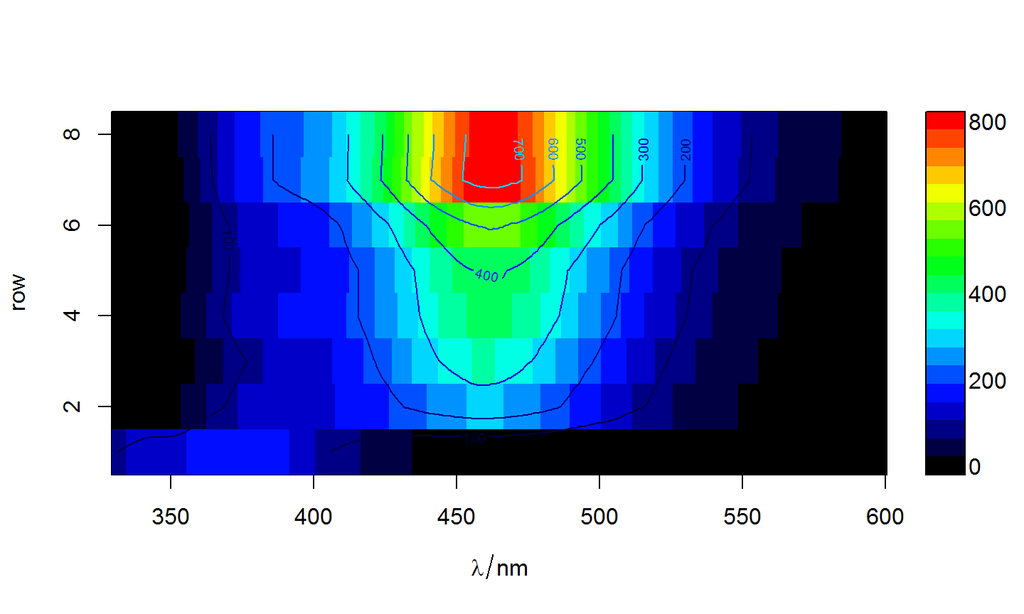

```r
plotmat(spec)
plotmat(spec, contour = TRUE, add= TRUE)
```

## Matrix Plot - IR Data

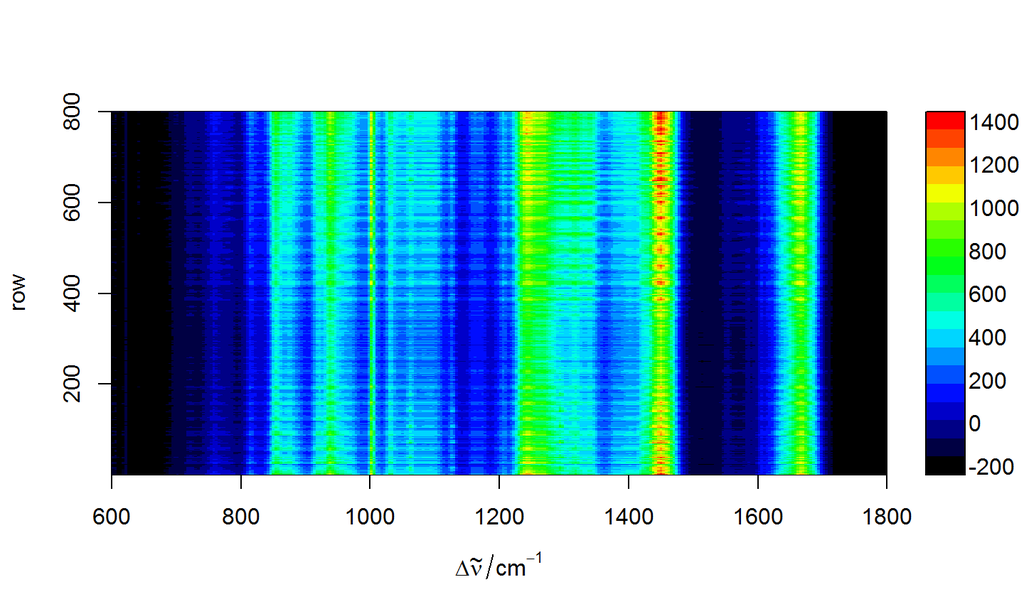

```r
plotmat(ir.spc)
```

## Stacked Spectra

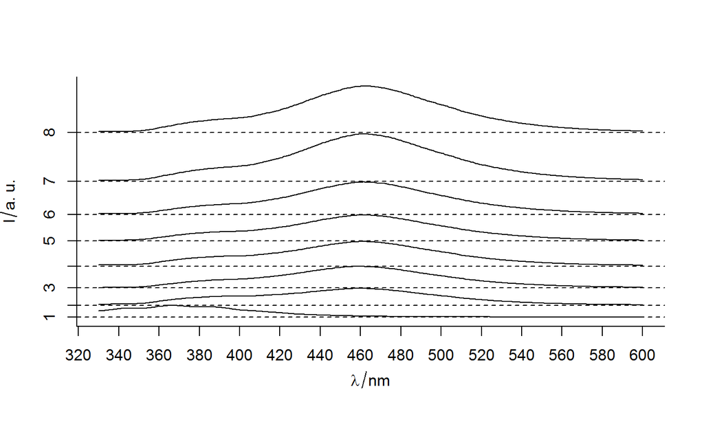

```r
plotspc(spec, stacked = TRUE)
```

## Summary

## hyperSpec

- hyperSpec is a powerful R package for handling and manipulating spectral data in R
- More to come!